# Chapter 3: Logistic regression

*This work includes performing and interpreting logistic regression analysis. Specifically, this work includes plotting the data frame, fitting logistic regression model, and interpreting results .*

## 3.1 read the data

This data approach student achievement in secondary education of two Portuguese schools. The data attributes include student grades, demographic, social and school related features) and it was collected by using school reports and questionnaires. Two datasets are provided regarding the performance in two distinct subjects: Mathematics (mat) and Portuguese language (por). The two datasets were modeled under binary/five-level classification and regression tasks.

```r
date()
```

```
## [1] "Tue Nov 22 03:36:31 2022"
```

```r
#library
library(GGally)
```

```r
library(ggplot2)
library(dplyr)
library(tidyverse)
# read the data into memory
library(readr)
alc <- read_csv("https://raw.githubusercontent.com/KimmoVehkalahti/Helsinki-Open-Data-Science/master/datasets/alc.csv", show_col_types=FALSE)
```

## 3.2 Choose the variables of interest

The purpose of your analysis is to study the relationships between high/low alcohol consumption and some of the other variables in the data. In this exercise, I choose famrel, studytime, age and freetime variables and study the relationship between the 4 variables and alcohol consumption. I assume that the famrel and studytime have nagative impact on alcohol consumption, while age and freetime have positive impact on it.

## 3.3 Graphical interpretation of the variables

This subchapter uses the box plots to explore the distributions of my chosen variables and their relationships with alcohol consumption.

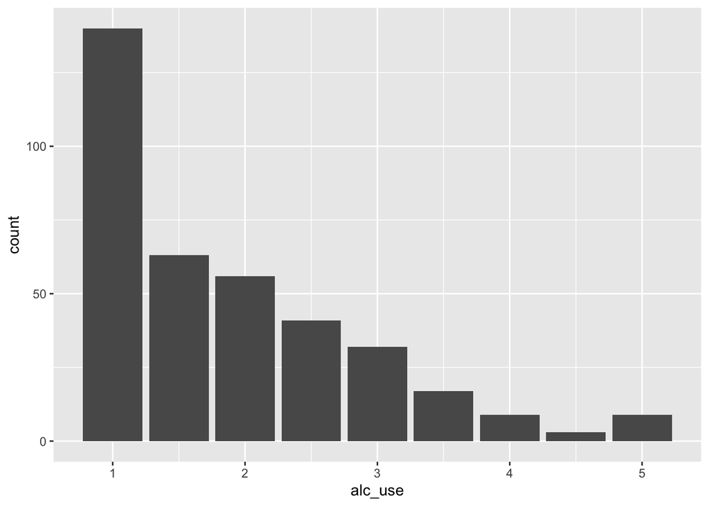

```r
#distribution plots using bar plot
# initialize a plot of alcohol use
g_1 <- ggplot(data = alc, aes(x = alc_use))
g_1 + geom_bar()
```

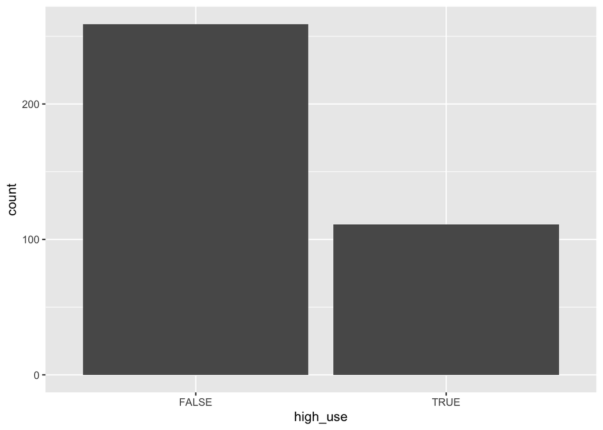

```r
g_2 <- ggplot(data = alc, aes(x = high_use))
g_2 + geom_bar()
```

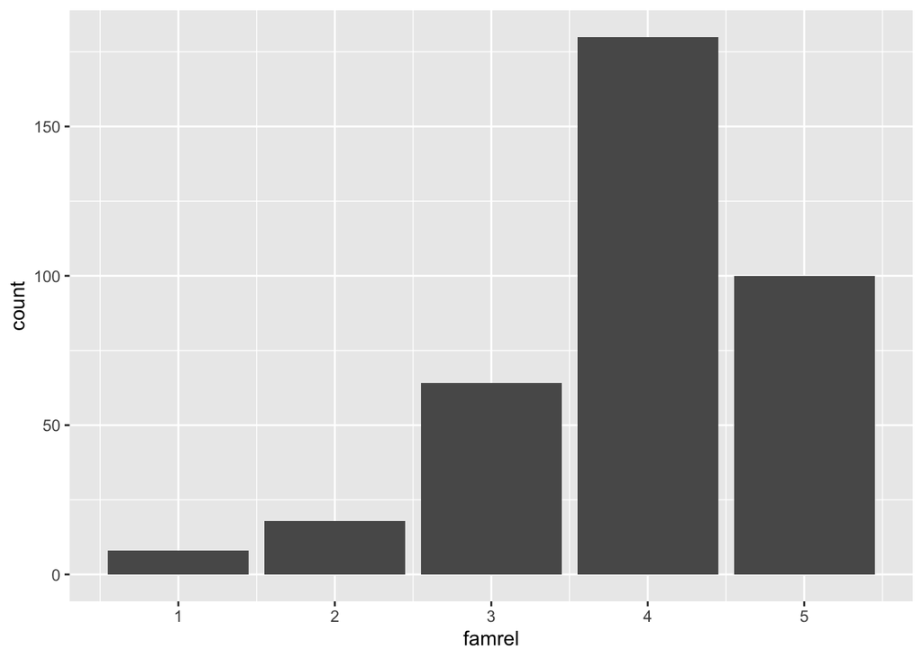

```r
g_3 <- ggplot(data = alc, aes(x = famrel))
g_3 + geom_bar()
```

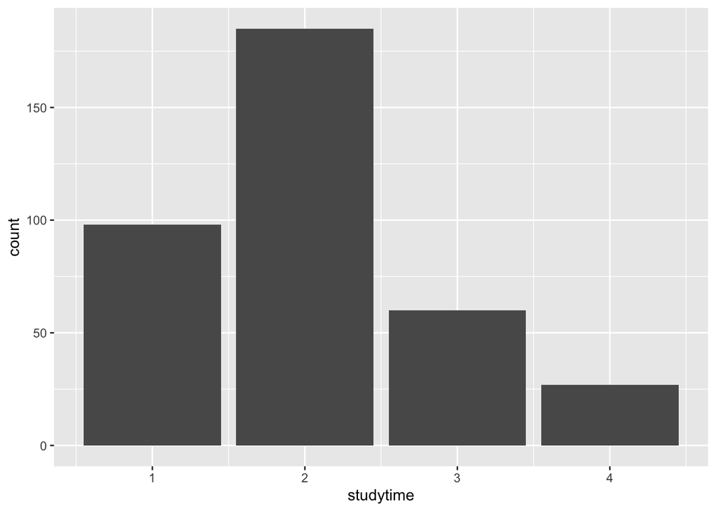

```r
g_4 <- ggplot(data = alc, aes(x = studytime))
g_4 + geom_bar()
```

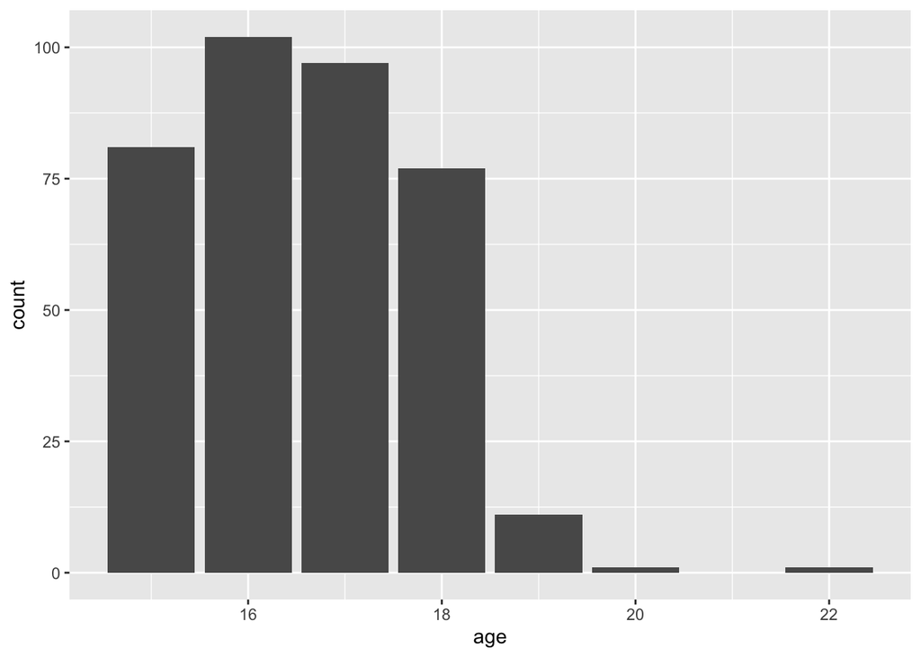

```r
g_5 <- ggplot(data = alc, aes(x = age))
g_5 + geom_bar()
```

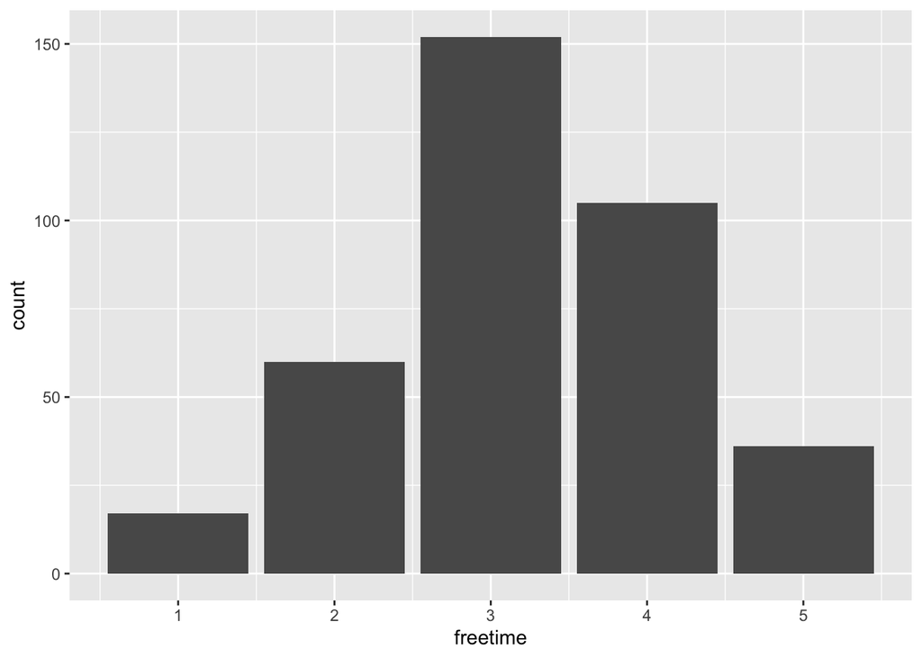

```r
g_6 <- ggplot(data = alc, aes(x = freetime))
g_6 + geom_bar()
```

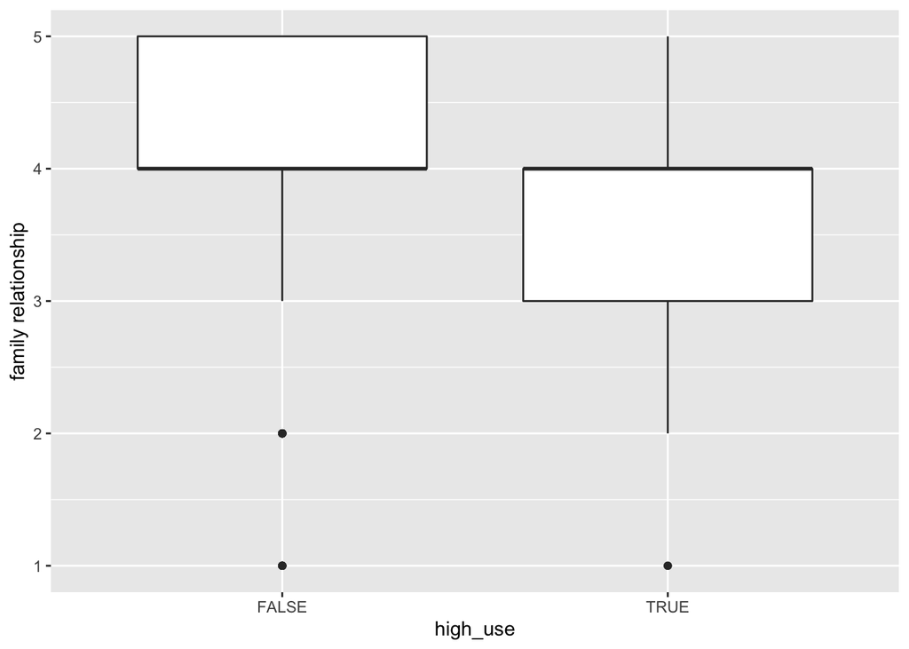

```r
# initialize a plot of high_use and famrel
g1 <- ggplot(alc, aes(x = high_use, y = famrel))

# define the plot as a boxplot and draw it
g1 + geom_boxplot() + ylab("family relationship")
```

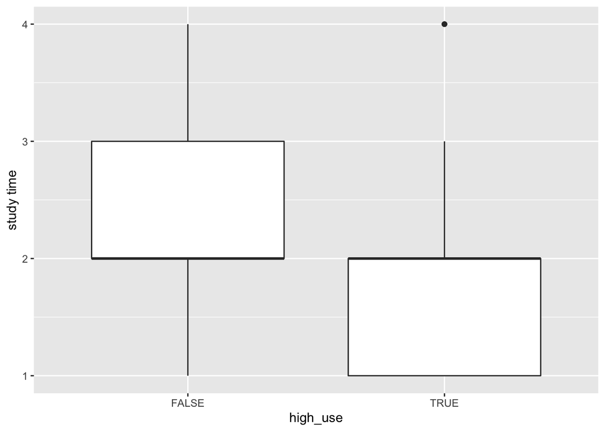

```r
# studytime and alchohol consumption
g2 <- ggplot(alc, aes(x = high_use, y = studytime))
g2 + geom_boxplot() + ylab("study time")
```

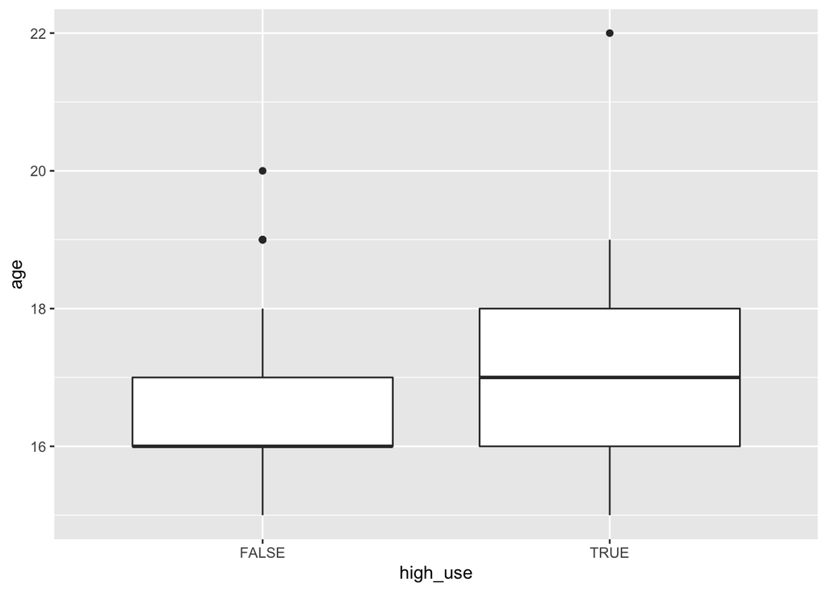

```r
# age and alchohol consumption
g3 <- ggplot(alc, aes(x = high_use, y = age))
g3 + geom_boxplot() + ylab("age")
```

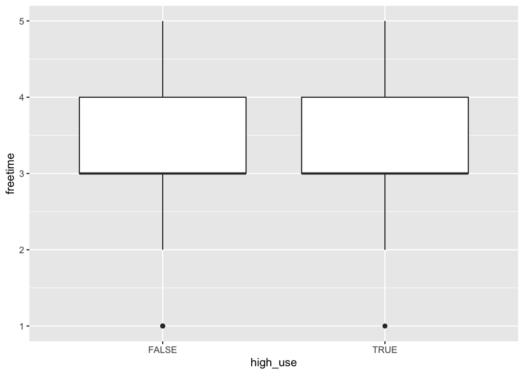

```r
# freetime and alchohol consumption
g4 <- ggplot(alc, aes(x = high_use, y = freetime))
g4 + geom_boxplot() + ylab("freetime")
```

## 3.4 logistic regression models

This part runs the logistic regression with the variables selected above

```r
# find the model with glm()
m <- glm(high_use ~ famrel + studytime + age + freetime, data = alc, family = "binomial")

summary(m)
```

```
##
## Call:
## glm(formula = high_use ~ famrel + studytime + age + freetime,
##     family = "binomial", data = alc)
##
## Deviance Residuals:
##     Min       1Q   Median       3Q      Max
## -1.7542  -0.8553  -0.6349   1.1722   2.2035
##
## Coefficients:
##             Estimate Std. Error z value Pr(>|z|)
## (Intercept)  -3.2910     1.8099  -1.818 0.069019 .
## famrel       -0.3542     0.1315  -2.693 0.007086 **
## studytime    -0.5725     0.1576  -3.632 0.000281 ***
## age           0.2221     0.1023   2.170 0.029983 *
## freetime      0.3793     0.1264   3.000 0.002701 **
## ---
## Signif. codes:  0 '***' 0.001 '**' 0.01 '*' 0.05 '.' 0.1 ' ' 1
##
## (Dispersion parameter for binomial family taken to be 1)
##
##     Null deviance: 452.04  on 369  degrees of freedom
## Residual deviance: 415.07  on 365  degrees of freedom
## AIC: 425.07
##
## Number of Fisher Scoring iterations: 4
```

```r
OR <- coef(m) %>% exp
CI <- confint(m)
cbind(OR, CI)
```

```
##                     OR       2.5 %      97.5 %
## (Intercept) 0.03721707 -6.88776678  0.23054128
## famrel      0.70173583 -0.61460703 -0.09722191
## studytime   0.56414042 -0.89131071 -0.27196009
## age         1.24866753  0.02362678  0.42612657
## freetime    1.46128242  0.13517480  0.63202911
```

## 3.5 Prediction

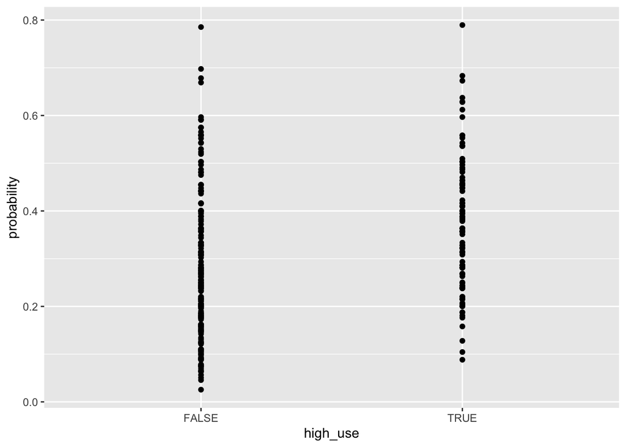

```
##         prediction
## high_use FALSE TRUE
##    FALSE   238   21
##    TRUE     92   19
```